# One-way ANOVA

2025

## Introduction

- One-way ANOVA (Analysis of Variance) is used to determine if there are **ANY** differences between the means of at least two (but usually three or more) independent groups based on one categorical independent variable.
- It’s a test for equality of means but it uses variances under the hood to make this determination.
- ANOVA is an **omnibus** test. If the test is significant, we know that at least one group is different from the others, but **NOT** which groups are different.

## Naming conventions

- A **one-way ANOVA** is used when there is one **between-subjects** factor.
- A **one-way repeated measures** ANOVA is used when there is one **within-subjects** factor. This will be covered in a seperate slide deck.

## What is a Factor?

- In the context of experiment design and ANOVAs, a **factor** is a categorical variable that defines the groups or conditions in your experiment.
- A factor is equivalent to an **independent variable** (see next slide).
- In `R`, a factor is a special type of categorical variable with a fixed set of possible values, called levels.

## Example

- A study investigating the effect of sleep deprivation on cognitive performance.
- **Independent Variable**: Amount of sleep (categorical with three levels, such as “Full 8 hours,” “4 hours,” and “No sleep”). This is what you control in your experiment design.
- **Dependent Variable**: Performance on a cognitive task measured by scores on a memory test or reaction times. This is a random variable that generates the data for your experiment.

## Assumptions of a One-way ANOVA

- **Independence**: Observations are independent and randomly sampled from the population within each factor level.
- **Normality**: The dependent variable is normally distributed within each population defined by the factor levels.
- **Homogeneity of variance**: The population variances are equal across factor levels. This is also called **homoscedasticity**.

## Visualising the assumptions

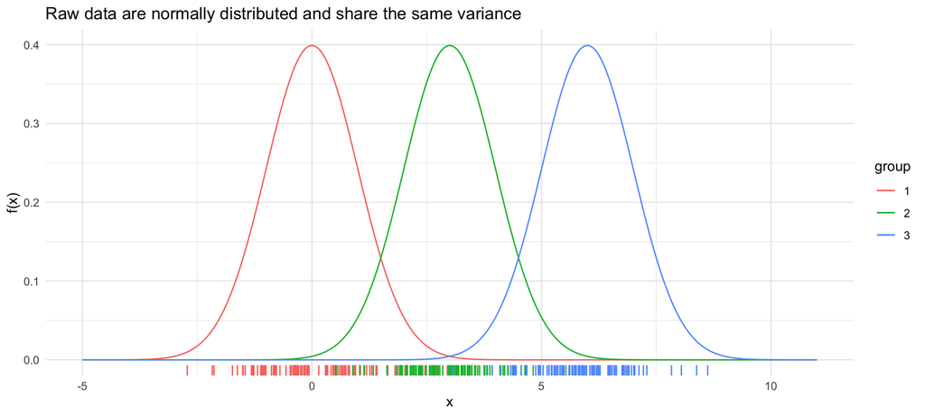

## Example data

```
##               x group subject
##           <num> <int>   <int>
##  1: -0.56047565     1       1
##  2: -0.23017749     1       2
##  3:  1.55870831     1       3
##  4:  0.07050839     1       4
##  5:  0.12928774     1       5
##  6:  4.71506499     2       6
##  7:  3.46091621     2       7
##  8:  1.73493877     2       8
##  9:  2.31314715     2       9
## 10:  2.55433803     2      10
## 11:  7.22408180     3      11
## 12:  6.35981383     3      12
## 13:  6.40077145     3      13
## 14:  6.11068272     3      14
## 15:  5.44415887     3      15
```

## One-way ANOVA: Hypotheses

\[ \begin{align} & H_0: \mu_1 = \mu_2 = \mu_3 \ldots \\ & H_1: \lnot H_0 \\ \end{align} \]

## One-way ANOVA: Hypotheses

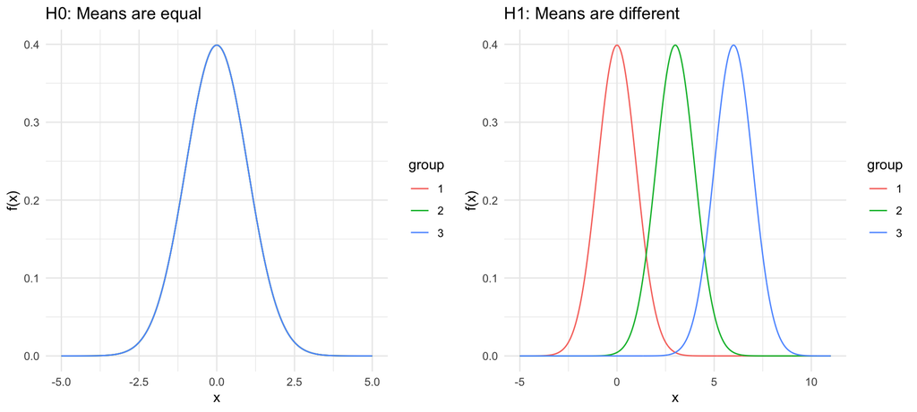

## One-way ANOVA: Hypotheses

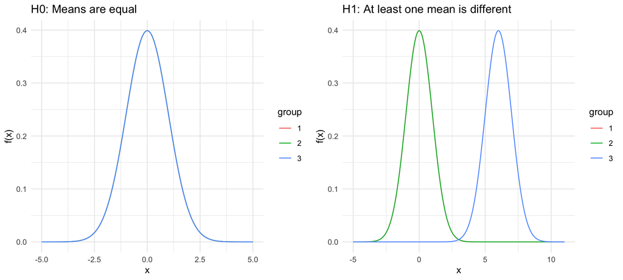

## Intuition

- **Between-group variation** — This captures the magnitude of the differences **between** the group means.
- **Within-group variation** — This captures magnitude of the differences **within** each group.
- If the means are all the same (i.e., \(H_0\) is true), then between-group and within-group variation should be equal.

## Intuition

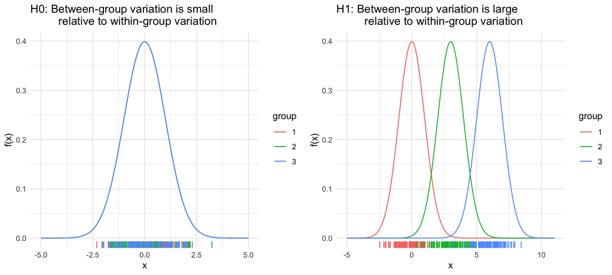

## Reframe the H’s

- We reframe our hypotheses from this:

\[ \begin{align} & H_0: \mu_1 = \mu_2 = \mu_3 \ldots \\ & H_1: \lnot H_0 \\ \end{align} \]

- To this:

\[ \begin{align} & H_0: \frac{\text{between-group variation}}{\text{within-group variation}} = 1 \\ & H_1: \frac{\text{between-group variation}}{\text{within-group variation}} > 1 \\ \end{align} \]

## ANOVA \(H_1\) is always one-sided

- ANOVA always uses an alternative hypothesis that is one-sided.
- We reject the null only if the between-group variability is significantly greater than the within-group variability.
- This corresponds to a *greater than* in \(H_1\).

## Reframe the H’s: formality

- Then from this:

\[ \begin{align} & H_0: \frac{\text{between-group variation}}{\text{within-group variation}} = 1 \\ & H_1: \frac{\text{between-group variation}}{\text{within-group variation}} > 1 \\ \end{align} \]

- To this:

\[ \begin{align} & H_0: \frac{\sigma^2_{between}}{\sigma^2_{within}} = 1 \\ & H_1: \frac{\sigma^2_{between}}{\sigma^2_{within}} > 1 \\ \end{align} \]

## What are \(\sigma^2_{\text{between}}\) and \(\sigma^2_{\text{within}}\)?

- First consider data from a simple experiment with three groups:

| Group 1 | Group 2 | Group 3 |
| --- | --- | --- |
| \(x_1\) | \(y_1\) | \(z_1\) |
| \(x_2\) | \(y_2\) | \(z_2\) |
| \(\ldots\) | \(\ldots\) | \(\ldots\) |
| \(x_l\) | \(y_m\) | \(z_n\) |

- If \(l=m=n\) then we have an equal number of observations for each group. When this is the case, we say that we have a **balanced design**.

## What are \(\sigma^2_{\text{between}}\) and \(\sigma^2_{\text{within}}\)?

- **Grand mean:**

\[ G = \frac{l \bar{x} + m \bar{y} + n \bar{z}}{l + m + n} = \frac{\bar{x} + \bar{y} + \bar{z}}{3} \text{ If design is balanced} \]

- **Between-group variation:** Reflects variation of group means around the grand mean.

\[ \text{SS}_{\text{between}} = l (\bar{x} - G)^2 + m (\bar{y} - G)^2 + n (\bar{z} - G)^2 \]

- **Within-group variation:** Reflects variation of individual scores around their group mean.

\[ \text{SS}_{\text{within}} = \sum_{i=1}^l (x_i-\bar{x})^2 + \sum_{i=1}^m (y_i-\bar{y})^2 + \sum_{i=1}^n (z_i-\bar{z})^2 \]

## \(SS\) **is not** a good estimate of \(\sigma^2_{\text{between}}\) and \(\sigma^2_{\text{within}}\)

- SS generally gets bigger as you have more values, even if the variability of the data stays the same.
- We need a way to standardize the SS so that it isn’t affected by the number of observations.
- Dividing SS by **degrees of freedom** produces a good estimate of the true variability in the population.

## \(MS\) **is** a good estimate of \(\sigma^2_{\text{between}}\) and \(\sigma^2_{\text{within}}\)?

- **Mean Squared error (MS)** is defined as:

\[ \text{MS}_{\text{between}} = \frac{\text{SS}_{\text{between}}}{\text{df}_{\text{between}}} \]

\[ \text{MS}_{\text{within}} = \frac{\text{SS}_{\text{within}}}{\text{df}_{\text{within}}} \]

## Degrees of freedom

- Degrees of freedom are the number of independent pieces of information available to estimate a parameter.
- The group means are tied together through the grand mean, costing 1 degree of freedom.
- **Between-group degrees of freedom:**  
  \[ df_{\text{between}} = n_{\text{groups}} - 1 \]
- Within each group, observations are tied together through their group mean, costing 1 degree of freedom per group.
- **Within-group degrees of freedom:**  
  \[ df_{\text{within}} = n_{\text{total}} - n_{\text{groups}} \]

## What we have so far

\[ \begin{align} & H_0: \frac{\sigma^2_{\text{between}}}{\sigma^2_{\text{within}}} = 1 \\ & H_1: \frac{\sigma^2_{\text{between}}}{\sigma^2_{\text{within}}} > 1 \\ & \widehat{\frac{\sigma^2_{\text{between}}}{\sigma^2_{\text{within}}}} = \frac{\text{MS}_{\text{between}}}{\text{MS}_{\text{within}}} \\\\ & \text{MS}_{\text{between}} = \frac{\text{SS}_{\text{between}}}{df_{\text{between}}} \\ & \text{MS}_{\text{within}} = \frac{\text{SS}_{\text{within}}}{df_{\text{within}}} \\\\ & df_{\text{between}} = n_{groups} - 1 \\ & df_{\text{within}} = n_{total} - n_{groups} \\\\ & n_{total} = l + m + n \\\\ \end{align} \]

- We still need to specify how our test statistic is distributed under the null hypothesis.

## Sampling distribution of the test statisic

\[ \begin{align} & \widehat{\frac{\sigma^2_{\text{between}}}{\sigma^2_{\text{within}}}} = \frac{\text{MS}_{\text{between}}}{\text{MS}_{\text{within}}} \sim F(df_{\text{between}}, df_{\text{within}})\\ & F_{obs} = \frac{\text{MS}_{\text{between}}}{\text{MS}_{\text{within}}} \sim F(df_{\text{between}}, df_{\text{within}})\\ \end{align} \]

## One-way ANOVA reciple summary

\[ \begin{align} & H_0: \frac{\sigma^2_{\text{between}}}{\sigma^2_{\text{within}}} = 1 \\ & H_1: \frac{\sigma^2_{\text{between}}}{\sigma^2_{\text{within}}} > 1 \\ & \widehat{\frac{\sigma^2_{\text{between}}}{\sigma^2_{\text{within}}}} = \frac{\text{MS}_{\text{between}}}{\text{MS}_{\text{within}}} \\\\ & \text{MS}_{\text{between}} = \frac{\text{SS}_{\text{between}}}{df_{\text{between}}} \\ & \text{MS}_{\text{within}} = \frac{\text{SS}_{\text{within}}}{df_{\text{within}}} \\\\ & df_{\text{between}} = n_{groups} - 1 \\ & df_{\text{within}} = n_{total} - n_{groups} \\\\ & n_{total} = l + m + n \\\\ & \widehat{\frac{\sigma^2_{\text{between}}}{\sigma^2_{\text{within}}}} = \frac{\text{MS}_{\text{between}}}{\text{MS}_{\text{within}}} \sim F(df_{\text{between}}, df_{\text{within}})\\ & F_{obs} = \frac{\text{MS}_{\text{between}}}{\text{MS}_{\text{within}}} \sim F(df_{\text{between}}, df_{\text{within}})\\ \end{align} \]

## What is an F distribution?

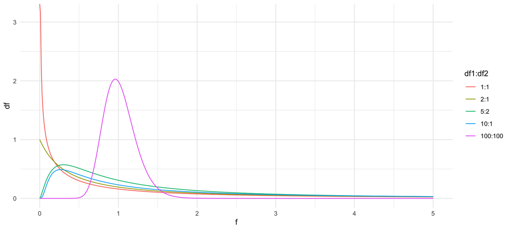

## P-values and decisions

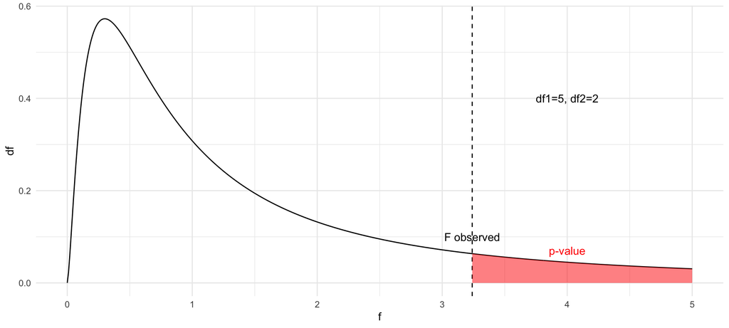

## One-Way ANOVA Table (for independent groups)

| **Source** | **Df** | **SS** | **MS** | **F** | **P(>F)** |
| --- | --- | --- | --- | --- | --- |
| Between groups | \(k-1\) | see above | \(\frac{SS_{between}}{Df_{between}}\) | \(\frac{MS_{between}}{MS_{within}}\) |  |
| Within groups | \(N-k\) | see above | \(\frac{SS_{within}}{Df_{within}}\) |  |  |
| Total | \(N-1\) | see above |  |  |  |

## ANOVA with `ez`

```
##               x group subject
##           <num> <int>   <int>
##  1: -0.56047565     1       1
##  2: -0.23017749     1       2
##  3:  1.55870831     1       3
##  4:  0.07050839     1       4
##  5:  0.12928774     1       5
##  6:  4.71506499     2       6
##  7:  3.46091621     2       7
##  8:  1.73493877     2       8
##  9:  2.31314715     2       9
## 10:  2.55433803     2      10
## 11:  7.22408180     3      11
## 12:  6.35981383     3      12
## 13:  6.40077145     3      13
## 14:  6.11068272     3      14
## 15:  5.44415887     3      15
```

## ANOVA with `ez`

```r
library(ez)
d[, group := factor(group)]
d[, subject := factor(subject)]
ezANOVA(data=d, dv=x, wid=.(subject), within=NULL, between=.(group), type=3)
```

## ANOVA with `ez`

- `data`: the data.table containing the data.
- `dv`: the dependent variable.
- `wid`: the subject identifier.
- `within`: the within-subjects factor.
- `between`: the between-subjects factor.
- `type`: the type of sum of squares to use.

## What are types of sum of squares?

- Type I: sequential sum of squares.
- Type II: partial sum of squares.
- Type III: marginal sum of squares.
- **We will always use Type III sum of squares.**

## `ez` ANOVA output

```r
library(ez)
d[, group := factor(group)]
d[, subject := factor(subject)]
ezANOVA(data=d, dv=x, wid=.(subject), within=NULL, between=.(group), type=3)
```

```
## $ANOVA
##   Effect DFn DFd        F            p p<.05       ges
## 2  group   2  12 58.10218 6.724665e-07     * 0.9063994
##
## $`Levene's Test for Homogeneity of Variance`
##   DFn DFd       SSn      SSd         F         p p<.05
## 1   2  12 0.4747922 5.082453 0.5605075 0.5851711
```

## `ez` ANOVA Output

- **Effect**: The factor(s) being tested (e.g., group).
- **DFn**: Degrees of freedom for the effect (numerator, between-groups).
- **DFd**: Degrees of freedom for the error term (denominator, within-groups).
- **F**: The F-statistic comparing group variance to error variance.
- **p**: The p-value for the F-test.
- **p<.05**: Whether the result is significant at the \(\alpha = 0.05\) level.
- **ges**: Generalized eta-squared, a measure of effect size.

## Levene’s Test for Homogeneity of Variance

- We won’t cover Levene’s test in detail.
- It’s a test to see if the variances of the groups are equal.
- I recommend checking assumptions visually with plots.
- More on assumption checking in later weeks.